# Analysis Protocol

Christian Diener, Osbaldo Resendis

# Installation

This repository is structured to enable easy installation of the required dependencies. This is enabled by the `prtools` R package that serves two major purposes:

1. It includes auxiliary functions and tests that are used during the analysis
2. It depends on all other R packages that are used throughout the analysis. Thus, installing the `prtools` package will also ensure that all other required packages are installed.

We also provide a Docker container which has everything pre-installed and can be used to run the analysis on a server in the cloud.

This repository also includes `<step>.R` files for all steps of the analysis which you can use to run parts of the analysis in an automated manner. Additional data file are also contained in this repository. In order to obtain a local copy you can clone the repository with [git](https://git-scm.org).

```bash
git clone cdiener/proliferation
```

## Local installation

For a local installation you will require `R` installed (see http://r-project.org for installation instructions). You will also require `Python` and `cobrapy` if you want to run the metabolic modeling part of the analysis.

To install the R dependencies, first install bioconductor and devtools if you do not have them installed already. Start up R and use the following:

```r
install.packages("devtools")
source("https://bioconductor.org/biocLite.R")
biocLite()
```

After that you can install `prtools` simply via

```r
devtools::install_github("cdiener/proliferation/prtools")
```

The Python dependencies can be installed via pip, however, that will take a while. We recommend installation with the Anaconda Python distribution (see https://www.continuum.io/downloads for installation instructions). You will require the version using Python 3. You can now install cobrapy from [bioconda](https://bioconda.github.io/) using the following commands in a Terminal:

```bash
conda install -c bioconda cobrapy
```

## Using the docker image

In order to run this image in the cloud you will need a server with docker installed. The easiest way to do so is to start a virtual machine that already has it installed such as the [CoreOS](https://coreos.com/) machines on Amazon AWS, Google Cloud or Digital Ocean.

Either run the following on your local machine or your cloud server:

```bash
docker run -d -p 8000:8787 cdiener/proliferation
```

Now navigate to http://your-ip:8000 on your local machine (ip will be “localhost”) or your server in the cloud in order to see an Rstudio client. You will be prompted for a user and password which are both set to “rstudio” by default.

# Getting the data

We will start by getting all the required data. You will need about 500 GB of disk space for all the downloads. This step is the longest during this analysis.

First, we will download the HuEx 1.0 ST exon expression data for the NCI-60 cell lines using the `GEOquery` package (about 9 GB).

```r
GEOquery::getGEOSuppFiles("GSE29682")
untar("GSE29682/GSE29682_RAW.tar", exdir="GSE29682")
```

We follow this by downloading all relevany TCGA data as well (about 310 GB). Here, we use the tcgar package which we wrote specifically for this analysis. We will save the data into the `TCGA` subfolder with another subfolder for each cancer panel.

```r
create.dir("TCGA")
setwd("TCGA")
panels <- tcgar::get_panels()
none <- sapply(panels, tcgar::get_data, tech=c("clinical", "HuEx", "RNASeqV2"))
setwd("..")
```

Finally, we will also get annotations that relate all the genes from the NCI-60 and TCGA data sets. Here, we will employ biomart to obtain mappings between the probes on the HuEx microarrays and several Gene ID systems. This step is optional since the generated `genemap.rds` file is contained in the repository as well.

```r
library(biomaRt)
library(data.table)

ensembl = useMart("ensembl",dataset="hsapiens_gene_ensembl")
attrs <- c("ensembl_gene_id", "description", "external_gene_name", "ucsc",
    "entrezgene", "affy_huex_1_0_st_v2")
genemap <- getBM(mart=ensembl, attributes=attrs)
genemap <- data.table(genemap)
names(genemap) <- c("ensgene", "description", "symbol", "ucsc", "entrez", "huex")
saveRDS(genemap, "genemap.rds")
```

# Preprocessing exon expression data

## Normalization and summary

We will start by preparing the HuEx exon expression data for the NCI-60 data set. Here, we will read all of the raw files, calculate the log expression values and normalize the arrays with RMA. This will take about 16 GB of RAM and take a while. If you have several cores available on your machine we recommend to use them here. To use 6 core for do the following:

```r
library(foreach)
doParallel::registerDoParallel(cl=6)
```

Finally, we will save this raw expression set to a serialized format, so we do not have to repeat this step every time. This will take about half an hour.

```r
library(prtools)
library(oligo)
library(data.table)
if (file.exists("eset_raw.rds")) eset <- readRDS("eset_raw.rds") else {
    celfiles <- list.celfiles(recursive=T, listGzipped=T)
    raw_data <- read.celfiles(celfiles)
    eset <- rma(raw_data, target="probeset")
    rm(raw_data)
    saveRDS(eset, file="eset_raw.rds")
}
```

The expression values we obtain this way are on the level of “probe sets”, sets of spots on the microarray. However, in order to obatin expression values per gene we have to summarize those probe set expression values. For this we can use `genemap.rds` mapping that we obtained earlier. First, we will prepare the genemap to give us unique mappings between genes and probe sets. We will only consider genes that map to a probe set that is present on our arrays and we will also only use probe sets that map to a gene with a known ENSEMBL ID.

```r
genemap <- readRDS("genemap.rds")
genemap <- unique(genemap, by=c("ensgene", "huex"))
genemap[, huex := as.character(huex)]
setkey(genemap, huex)
eset <- eset[rownames(eset) %in% genemap$huex, ]
genemap <- genemap[huex %in% rownames(eset) & !is.na(ensgene)]
```

We now have a mapping of probe sets to genes and vice versa. We will use that to summarize the log gene expression values into the geometric mean for each gene. For that we can use the `eset_reduce` function from the `prtools` package which does that rapidly (because it is implemented in C++).

```r
eset <- eset_reduce(eset, genemap$huex, genemap$ensgene)
```

## Joining with proliferation data

We now have the per-gene log expression values for each of the 178 microarrays in our data set. In order to map those arrays to their respective cell line we can use the annotations contained in `samples.csv`:

```r
samples <- fread("samples.csv")
head(samples)
```

```
##       geo_id  tumor  cell_line
## 1: GSM736050 Breast     BT-549
## 2: GSM736051 Breast     HS578T
## 3: GSM736052 Breast       MCF7
## 4: GSM736053 Breast MDA-MB-231
## 5: GSM736054 Breast       T47D
## 6: GSM736055    CNS     SF-268
```

So we see that there are 2-3 reptitions for each cell line. The actual growth rates are contained in `growth_rates.csv`:

```r
gcs <- fread("growth_rates.csv")
head(gcs)
```

```
##    cell_line panel_name doubling_time inoculation_density
## 1:  CCRF-CEM   Leukemia          26.7               40000
## 2:     HL-60   Leukemia          28.6               40000
## 3:     K-562   Leukemia          19.6                5000
## 4:    MOLT-4   Leukemia          27.9               30000
## 5: RPMI-8226   Leukemia          33.5               20000
## 6:        SR   Leukemia          28.7               20000
```

Now, we will reduce the individual repetitions for each cell line to its mean log expression values and relate the cell lines in the microarray samples to the ones in the gowth rate data set.

```r
setkey(gcs, cell_line)
cell_lines <- intersect(gcs$cell_line, samples$cell_line)
eset_summ <- sapply(cell_lines, function(cl) rowMeans(exprs(eset)[,samples$cell_line==cl]))
colnames(eset_summ) <- cell_lines
```

Right, now proliferation is given in doubling time (in hours), so we will convert those to proliferation rates and also run a quick check whether the proliferation rates are ordered the same way as the microarray samples.

```r
rates <- gcs[cell_lines, log(2)/doubling_time]
names(rates) <- cell_lines
if (all(colnames(eset_summ) == names(rates))) cat("Ordering is the same :)")
```

```
## Ordering is the same :)
```

## Exporting the regression problem

Finally, we will attach the proliferation rates as an aditional columns to the expression values, thus, each row now denotes a cell line, and each column a gene, where only the last column denotes the proliferation rates. This is a common format for regression and classification problems and we will save it in csv format, so that it can be used easily in other software.

```r
export <- data.table(t(eset_summ))
export[, "rates" := rates]
readr::write_csv(export, "regprob.csv")
```

# Preparing TCGA data

## Reading the data

First we will start by reading the TCGA data into RAM. The `tcgar` package does this efficiently and stores the results in a list with one sublist for each technology.

First, we identify all the cancer panels folders:

```r
folders <- dir("TCGA", pattern="[A-Z]{2,4}$", include.dirs=T)
folders <- file.path("TCGA", folders)
head(folders)
```

```
## [1] "TCGA/ACC"  "TCGA/BLCA" "TCGA/BRCA" "TCGA/CESC" "TCGA/CHOL" "TCGA/CNTL"
```

Now we can read the data using `read_bulk` function from `tcgar`. Again, we will save the output in a serialized file.

```r
library(tcgar)

if (!file.exists("tcga.rds")) {
    tcga <- read_bulk(folders)
    saveRDS(tcga, file="tcga.rds")
} else tcga <- readRDS("tcga.rds")
```

## Comparison to NCI-60 cell line data

In order to compare gene expression between the TCGA RNA-Seq data and NCI-60 microarrays we will need to create a data set that contains the mean expression values for all genes that are contained in the TCGA *and* NCI-60 data. For that, we begin by calculating the mean log expression values across all samples within the TCGA and NCI-60 data (RNA-Seq abundances are measured in counts, so we have to add a pseudo count in order to obtain the log). We begin by calculating the means for the RNA-Seq and HuEx data contained in the TCGA data set.

```r
all_rnaseq <- log(rowMeans(tcga$RNASeqV2$counts)+1, 2)
all_rnaseq <- data.table(entrez=tcga$RNASeqV2$features$entrez,
    tcga_rnaseq=all_rnaseq)
all_huex <- data.table(symbol=tcga$HuEx$features$symbol,
    tcga_huex=rowMeans(tcga$HuEx$assay))
```

We also do the same for the NCI-60 HuEx data.

```r
nci60 <- fread("regprob.csv", header=T)
rates <- nci60$rates
nci60[, rates := NULL]
all_nci60 <- data.table(ensgene=colnames(nci60), nci60_huex=colMeans(nci60))
```

We will now join those data sets by mapping their respective IDs. `tcgar` already comes with a table mapping the genes in TCGA between different IDs, `rnaseq_bm`.

```r
join <- merge(as.data.table(rnaseq_bm), all_nci60, by="ensgene")
join <- merge(join, all_huex, by="symbol")
join <- merge(join, all_rnaseq, by="entrez")
head(join)
```

```
##       entrez symbol         ensgene
## 1:         1   A1BG ENSG00000121410
## 2:        10   NAT2 ENSG00000156006
## 3:       100    ADA ENSG00000196839
## 4:      1000   CDH2 ENSG00000170558
## 5: 100008586  GAGE1 ENSG00000205777
## 6:     10001   MED6 ENSG00000133997
##                                                                                 description
## 1:                                   alpha-1-B glycoprotein [Source:HGNC Symbol;Acc:HGNC:5]
## 2: N-acetyltransferase 2 (arylamine N-acetyltransferase) [Source:HGNC Symbol;Acc:HGNC:7646]
## 3:                                    adenosine deaminase [Source:HGNC Symbol;Acc:HGNC:186]
## 4:             cadherin 2, type 1, N-cadherin (neuronal) [Source:HGNC Symbol;Acc:HGNC:1759]
## 5:                                           G antigen 1 [Source:HGNC Symbol;Acc:HGNC:4098]
## 6:                           mediator complex subunit 6 [Source:HGNC Symbol;Acc:HGNC:19970]
##    nci60_huex tcga_huex tcga_rnaseq
## 1:   6.679100  6.642225   11.579584
## 2:   3.207774  3.668125    5.785704
## 3:   7.078723  7.577961    9.674954
## 4:   7.306053  8.570602   10.935650
## 5:   5.177204  3.580848    1.046207
## 6:   6.790840  7.428435    9.777354
```

Sometimes, those mapping between IDs are not unique, which makes it impossible to identify unique gene expression values. We will remove those cases.

```r
dupes <- join$ensgene[duplicated(join$ensgene)]
print(sum(join$ensgene %in% dupes))
```

```
## [1] 30
```

```r
join <- join[!(join$ensgene %in% dupes), ]
saveRDS(join, "join.rds")
```

That gives us our joined gene expression data set.

## Identifying genes with conserved expression

In order to use gene expression data from the NCI-60 data set for predictions on the TCGA data set, we first have to find a set of genes with very similar expression values between cell lines and human samples. As described in the manuscript, we consider gene expression to be conserved if the expression values are correlated, meaning that the gene expression values between the two data sets follow a linear relationship. We could estimate the slope and intercept directly from TCGA RNA-Seq and NCI-60 HuEx data, however, a more stable approach is to estimate both parameters independently from addtional data we have.

### Estimating the intercept

The intercept describes a constant difference in log expression values between the two data set. We can estimate is simply by using data obtained with the same technology between the two data sets. Since we have HuEx expression data from NCI-60 as well as the TCGA data set, the intercept can be calculated as the difference in mean between the HuEx data sets.

```r
norm_int <- mean(join$nci60_huex) - mean(join$tcga_huex)
```

As we can see, using this correction both HuEx data sets relate well with each other.

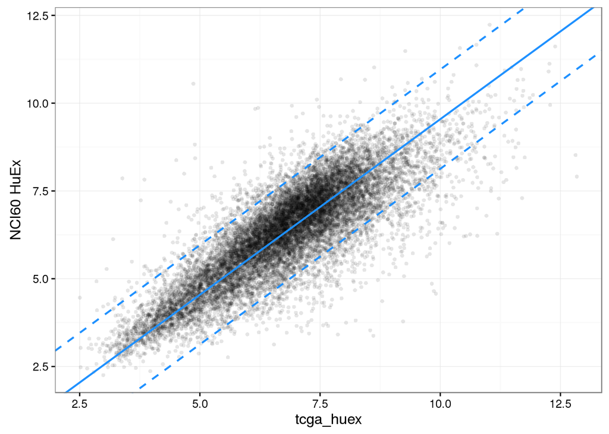

```r
library(ggplot2)

ggplot(join, aes(x=tcga_huex, y=nci60_huex)) + geom_point(alpha=0.1, stroke=0) +
    geom_abline(intercept=norm_int, size=3/4, col="dodgerblue") +
    geom_abline(intercept=sqrt(2)+norm_int, size=3/4, col="dodgerblue", linetype="dashed") +
    geom_abline(intercept=-sqrt(2)+norm_int, size=3/4, col="dodgerblue", linetype="dashed") +
    ylab("NCI60 HuEx") + theme_bw()
```

Here, the dashed blue lines denote the area in which genes have a maximum distance of 1 from the 1:1 relation denotes by the solid blue line.

### Estimating the slope

The slope of the linear relationship denotes a difference between technologies. It can be obtained by comparing the two technologies, HuEx and RNA-Seq, within the same data set.

```r
norm_slope <- coef(glm(tcga_huex ~ tcga_rnaseq + 0, data=join))
```

Again, we see that the majority of genes follows this relationship. However, there also some genes whose expression values are not comparable, even within the TCGA data set.

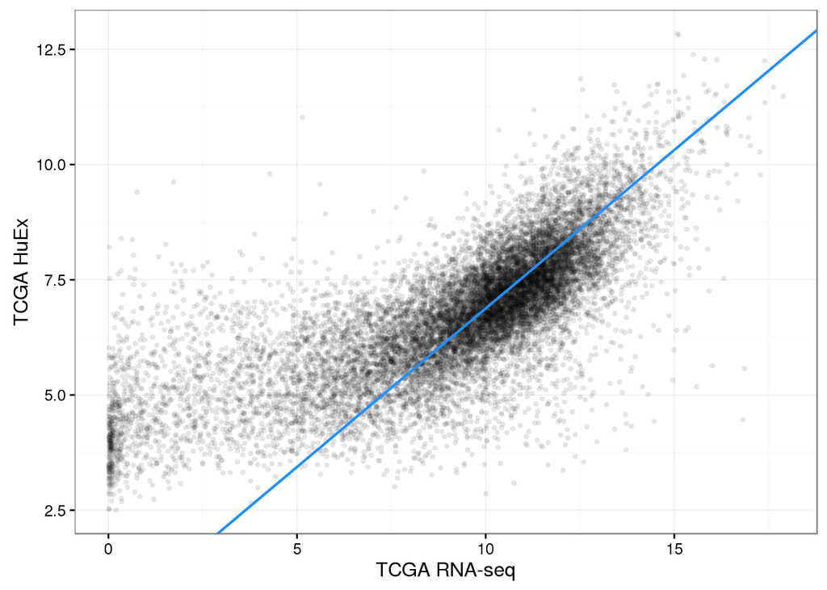

```r
ggplot(join, aes(x=tcga_rnaseq, y=tcga_huex)) + geom_point(alpha=0.1, stroke=0) +
    geom_abline(slope=norm_slope, size=3/4, col="dodgerblue") +
    xlab("TCGA RNA-seq") + ylab("TCGA HuEx") + theme_bw()
```

### Validation

Finally, we can validate the two parameters by using the TCGA RNA-Seq data and the NCI-60 HuEx data.

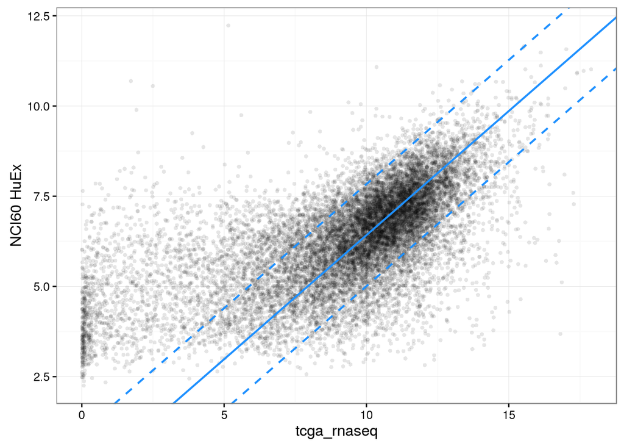

```r
ggplot(join, aes(x=tcga_rnaseq, y=nci60_huex)) + geom_point(alpha=0.1, stroke=0) +
    geom_abline(slope=norm_slope, intercept=norm_int, size=3/4, col="dodgerblue") +
    geom_abline(slope=norm_slope, intercept=sqrt(2)+norm_int, size=3/4, col="dodgerblue", linetype="dashed") +
    geom_abline(slope=norm_slope, intercept=-sqrt(2)+norm_int, size=3/4, col="dodgerblue", linetype="dashed") +
    ylab("NCI60 HuEx") + theme_bw()
```

```r
measures(join$nci60_huex, norm_slope * join$tcga_rnaseq + norm_int)
```

```
##        mse       rmse        mae        mre        rsq
##  3.1330149  1.7700324  1.2355934  0.2244203 -0.5881474
```

# Regression and prediction

We now have a way of normalizing the gene expression data between TCGA and NCI-60 and a criterion to select conserved genes only. Thus, we can now start with the regression problem. We start by reading the regression problem again.

```r
rdata <- fread("regprob.csv", header=T)
```

But this time we will only select the genes that conserved (difference in normalized log expression smaller than one).

```r
good <- join[(tcga_rnaseq*norm_slope + norm_int - nci60_huex)^2 < 1 &
    (tcga_huex + norm_int - join$nci60_huex)^2 < 1, ensgene]
rates <- rdata$rates
rdata[, "rates" := NULL]
rdata <- as.matrix(rdata)[, good]
dim(rdata)
```

```
## [1]   57 7540
```

We will now test a total of 4 different generalized linear models.

## Tested models

```r
library(glmnet)
pred <- data.frame()
m <- data.frame()
```

### First order model

In the first model gene expression values enter as linear variables into the model. We will extract the predictions on the training set as well as predictions from leave-one-out cross validation.

```r
mod1 <- cv.glmnet(rdata, rates, nfolds=length(rates), keep=T, parallel=T,
    grouped=FALSE, standardize=FALSE)
pred_train <- predict(mod1, rdata, s="lambda.min")[,1]
pred_test <- mod1$fit.preval[, which.min(mod1$cvm)]
```

We now append the predicted rates and performance measures to our data frames.

```r
pred <- rbind(pred, data.frame(truth=rates, pred=pred_train, set="train", order="1st"))
pred <- rbind(pred, data.frame(truth=rates, pred=pred_test, set="validation", order="1st"))
m <- rbind(m, data.frame(t(measures(rates, pred_train)), set="train", order="1st"))
m <- rbind(m, data.frame(t(measures(rates, pred_test)), set="validation", order="1st"))
```

### Second order model

```r
nonzero <- abs(coef(mod1, s="lambda.min")[-1]) > 0
data2 <- inter(rdata[,nonzero])
mod2 <- cv.glmnet(data2, rates, nfolds=10, keep=T, parallel=T,
    grouped=FALSE, standardize=FALSE)
pred_train <- predict(mod2, data2, s="lambda.min")[,1]
pred_test <- mod2$fit.preval[, which.min(mod2$cvm)]
pred <- rbind(pred, data.frame(truth=rates, pred=pred_train, set="train", order="2nd"))
pred <- rbind(pred, data.frame(truth=rates, pred=pred_test, set="validation", order="2nd"))
m <- rbind(m, data.frame(t(measures(rates, pred_train)), set="train", order="2nd"))
m <- rbind(m, data.frame(t(measures(rates, pred_test)), set="validation", order="2nd"))
```

### First and second order model

In this model we will use the same interaction terms as before but also add all the original gene expression values in order to see whether the model can be improved.

```r
data12 <- cbind(rdata[, nonzero], data2)
mod3 <- cv.glmnet(data12, rates, nfolds=length(rates), keep=T, parallel=T,
    grouped=FALSE, standardize=FALSE)
pred_train <- predict(mod3, data12, s="lambda.min")[,1]
pred_test <- mod3$fit.preval[, which.min(mod3$cvm)]
pred <- rbind(pred, data.frame(truth=rates, pred=pred_train, set="train", order="1st and 2nd"))
pred <- rbind(pred, data.frame(truth=rates, pred=pred_test, set="validation", order="1st and 2nd"))
m <- rbind(m, data.frame(t(measures(rates, pred_train)), set="train", order="1st and 2nd"))
m <- rbind(m, data.frame(t(measures(rates, pred_test)), set="validation", order="1st and 2nd"))
print(m)
```

```
##            mse         rmse          mae        mre       rsq        set
## 1 3.245004e-06 0.0018013895 0.0014491095 0.06926672 0.9418708      train
## 2 4.139532e-05 0.0064339193 0.0050504304 0.24158670 0.2584669 validation
## 3 8.995107e-07 0.0009484254 0.0006917722 0.03280561 0.9838867      train
## 4 1.146869e-05 0.0033865458 0.0025750277 0.12209251 0.7945561 validation
## 5 8.580864e-07 0.0009263295 0.0006768085 0.03215175 0.9846287      train
## 6 8.516852e-06 0.0029183647 0.0022775838 0.10667563 0.8474338 validation
##         order
## 1         1st
## 2         1st
## 3         2nd
## 4         2nd
## 5 1st and 2nd
## 6 1st and 2nd
```

### Regularized model by cutoff

Finally, we will try to improve the generalization of the model, by removing those interactions that have only very influences on the model and may thus be related to overfitting.

```r
cat("Reducing model by cutoff\n")
```

```
## Reducing model by cutoff
```

```r
cf <- as.numeric(coef(mod2, s="lambda.min"))[-1]
names(cf) <- rownames(coef(mod2))[-1]
nonzero <- abs(cf) > 1e-5
data_red <- data2[, nonzero]
mod <- cv.glmnet(data_red, rates, nfolds=length(rates), keep=T,
    grouped=FALSE, standardize=FALSE)
pred_train <- predict(mod, data_red, s="lambda.min")[,1]
pred_test <- mod$fit.preval[, which.min(mod$cvm)]
pred <- rbind(pred, data.frame(truth=rates, pred=pred_train, set="train", order="2nd + cutoff"))
pred <- rbind(pred, data.frame(truth=rates, pred=pred_test, set="validation", order="2nd + cutoff"))
m <- rbind(m, data.frame(t(measures(rates, pred_train)), set="train", order="2nd + cutoff"))
m <- rbind(m, data.frame(t(measures(rates, pred_test)), set="validation", order="2nd + cutoff"))
print(sum(nonzero))
```

```
## [1] 32
```

## Model selection

If we compare the goodness-of-fit measures we can see that the cutoff model shows good good performance with an error of about 6% in predicting proliferation rates.

goodnes-of-fit measures

| mse | rmse | mae | mre | rsq | set | order |
| --- | --- | --- | --- | --- | --- | --- |
| 3.20e-06 | 0.0018014 | 0.0014491 | 0.0692667 | 0.9418708 | train | 1st |
| 4.14e-05 | 0.0064339 | 0.0050504 | 0.2415867 | 0.2584669 | validation | 1st |
| 9.00e-07 | 0.0009484 | 0.0006918 | 0.0328056 | 0.9838867 | train | 2nd |
| 1.15e-05 | 0.0033865 | 0.0025750 | 0.1220925 | 0.7945561 | validation | 2nd |
| 9.00e-07 | 0.0009263 | 0.0006768 | 0.0321518 | 0.9846287 | train | 1st and 2nd |
| 8.50e-06 | 0.0029184 | 0.0022776 | 0.1066756 | 0.8474338 | validation | 1st and 2nd |
| 7.00e-07 | 0.0008501 | 0.0006285 | 0.0307343 | 0.9870555 | train | 2nd + cutoff |
| 3.10e-06 | 0.0017641 | 0.0013494 | 0.0651082 | 0.9442552 | validation | 2nd + cutoff |

This can also be observed visually by plotting the real proliferation rates against the predicted ones (a perfect match would create a 1:1 line).

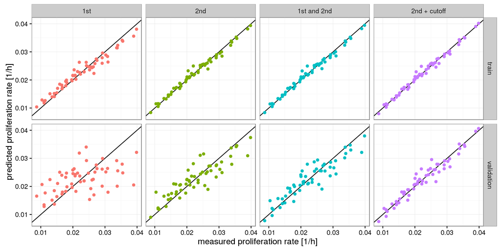

```r
ggplot(pred, aes(x=truth, y=pred, col=order)) + geom_abline() +
    geom_point() + facet_grid(set ~ order) + theme_bw() +
    xlab("measured proliferation rate [1/h]") +
    ylab("predicted proliferation rate [1/h]") +
    theme(legend.position="none")
```

## Prediction of proliferation rates